# TOA Bug 15

Brett Stacy

30 September 2019

# CPUE in Planetfish

Using CPUE as a relative index of abundance instead of tagging data for absolute abundance.

## CPUE Compared to Tagging

What happens when CPUE is used instead of tagging data in the same scenario? Below are the results of the simulations that are the same in every way except the abundance variables. Notice the scenario using tagging data is the best-performing example I have and the one I’m currently using as a baseline for the IUU paper.

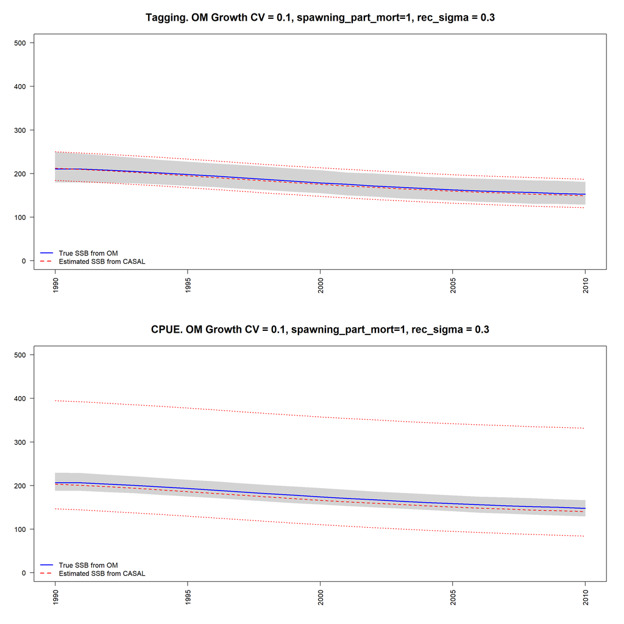

Figure 1. Tag and CPUE based simulations with the same parameterizations. spawning_part_mort=1 refers to the annual cycle of dynamics in CASAL. A value of 0.5 means half of mortality is applied before recording SSB. A value of 1 means all of mortality is applied before recording SSB.

### Conclusion:

The accuracy for which the AM estimates the OM SSB is comparable between the tagging case and CPUE case. The precision is quite different, however, with the error bars much wider in the CPUE case then the tagging case.

## Changing Growth CV in CPUE Simulation

Below illustrates the impact of changing the CV related to the Von Bertalanffy growth parameters passed to Planetfish on assessment performance. This time, CPUE is used for abundance instead of tagging data.

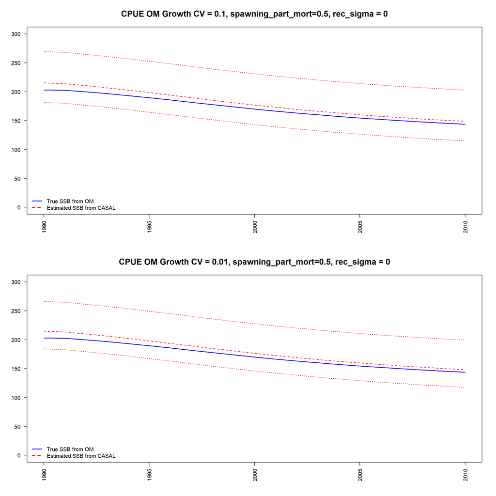

Figure 2. CPUE based simulations with different von Bert. growth CVs. spawning_part_mort=0.5 refers to the annual cycle of dynamics in CASAL. A value of 0.5 means half of mortality is applied before recording SSB. A value of 1 means all of mortality is applied before recording SSB.

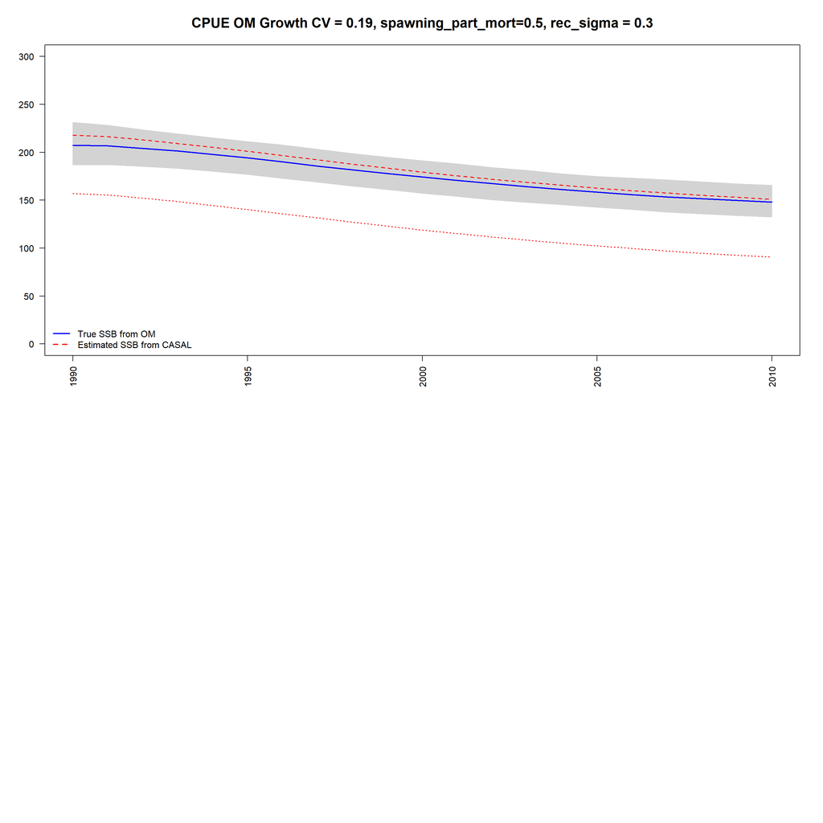

### Conclusion:

Changing growth CV does not impact the SSB discrepancy when using CPUE for abundance. This is contrary to situation when using tagging, where the CV dramatically impacts it. I conclude from this that the von-Bertalanffy growth CV set in the operating model has an unreasonable effect on the calculation of SSB in the AM and this effect is transmitted through the tagging array that gets generated from the OM and passed to the AM.